# Lab 1

February 21 2017

## Course aims and structure

- The main goal of this course is to familiarize students with practical knowledge and theoretical background of more advanced data analysis methods.
- We will aim to the level where you will be able to perform by yourself analyses required for your empirical paper, master thesis, and papers in professional psychological journals.
- Each lab will begin with short introduction and discussion of the topic, next you will use your knowledge to analyse real word datasets.
- Home assignments will mostly consist of writing short empirical reports, when you will practice your knowledge even further.
- To preserve your knowledge you will write 2 exams (midterm and final)

## How to pass the course?

- Students must respect the principles of academic integrity
- Attendance: 2 miss classes without excuse, 2 more classes in case of excuse (additional work), more than 4 will not pass
- Home assignments
- Midterm and final exam
- 30% * (home assignments) + 30% * (midterm score) + 40% * (final exam score) = total score
- Total score and both exam scores should be at least at the 50% level to pass the course.
- Grading scale: 95%+ = 5! 90-94% = 5 80-89% = 4.5 70-79% = 4 60-69% = 3.5 50-59% 59% = 3 below 50% = 2 (fail)

## Data analysis workflow

- Collecting your data, ie. running a study
- Importing your data to stat. software and checking its integrity
- Assessing whether data are adequate to answer the research question
- Making necessary transformations, computations, filtering, etc.
- Building a statistical model that will account for the data
- Diagnosing problems with the model and the data
- Assessing whether statistical model fits the data
- If model accepted: Drawing conclusions from the model – if not repeat 3 last steps (but with different model)
- Decide whether to collect more data

## Data analysis tools

- Graphical user interface, non-free: SPSS, Statistica, Stata, Excel
- Graphical user interface, free: JASP, PSPP
- Command line interface, non-free: Stata, SAS, S+, MATLAB
- Command line interface, free: R, some Python packages, Julia

## Tidy data 1

- Each variable forms a column
- Each observation forms a row
- Each type of observational unit forms a table -> Each cell consists of 1 value from 1 subject

| name | gender | age | self-esteem (1-4) |
| --- | --- | --- | --- |
| Dan | male | 69 | 3.6 |
| Brian | male | 64 | 3.7 |
| Sue | female | 65 | 3.9 |
| Hazel | female | 68 | 3.8 |

## Tidy data 2

- Ordering of columns - first fixed values, then random values
- Missing values are identified
- Value meaning is indicated (where possible)
- Scale type is identified

## Assumptions 1

- Normally distributed data

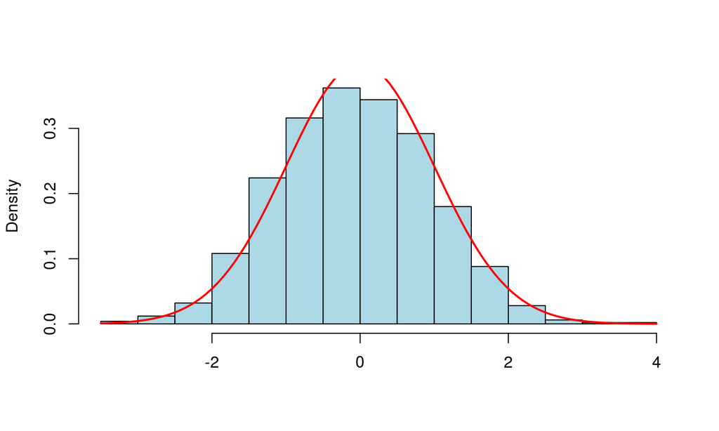

## Assumptions 1

- Non-normally distributed data

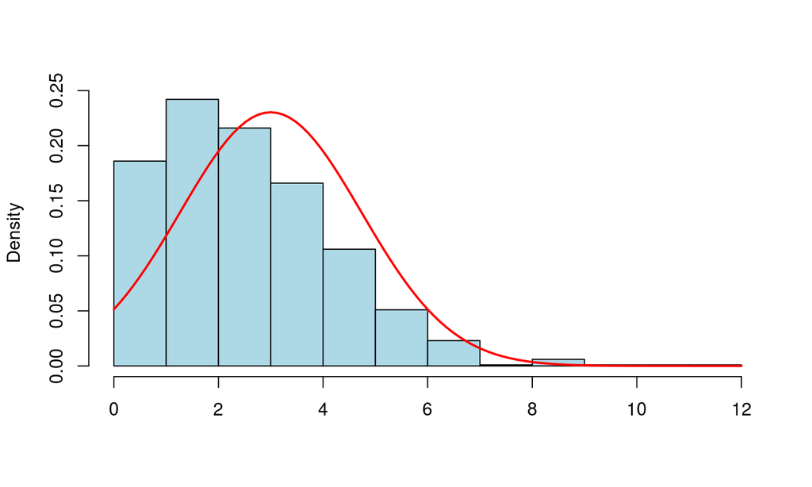

## Assumptions 2

- Homogeneity of variance

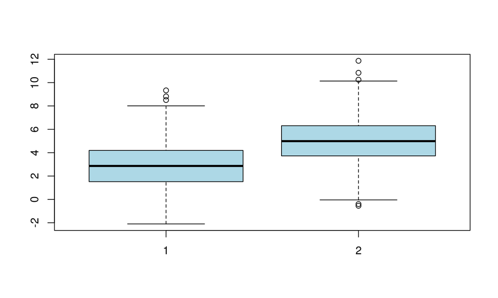

## Assumptions 2

- Heterogeneity of variance

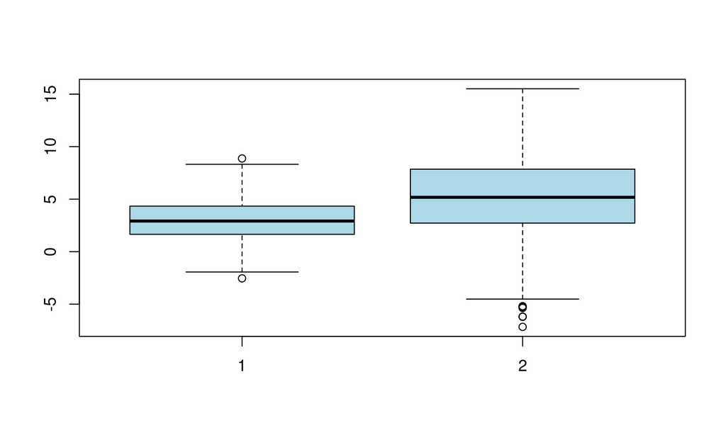

## Assumptions 3

- Interval data

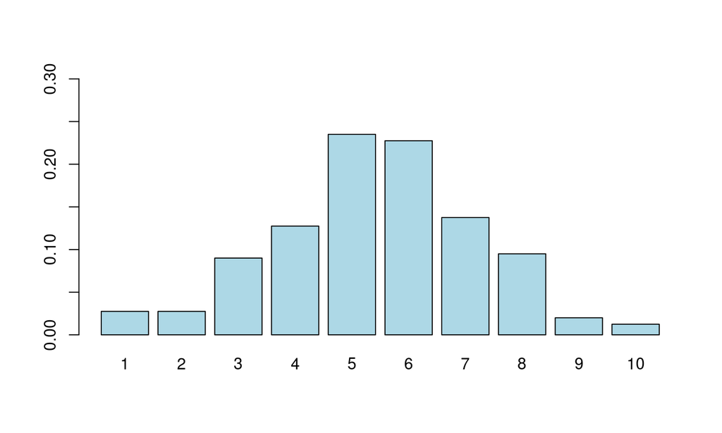

## Assumptions 3

- Non-interval data

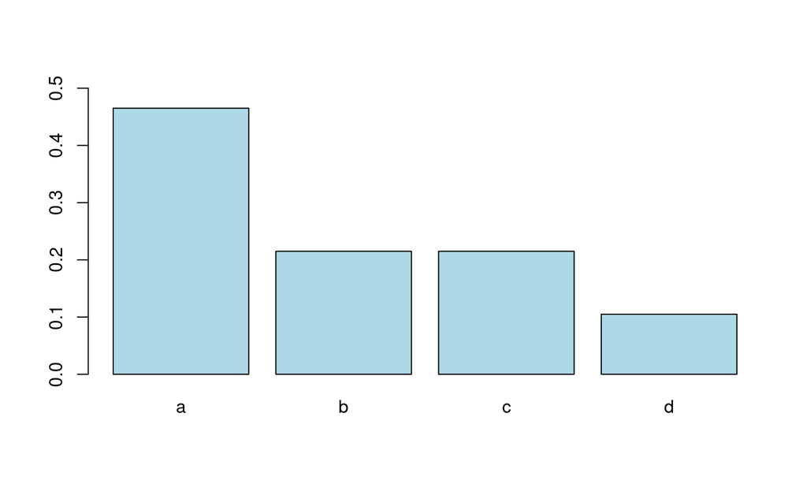

## Assumptions 4

- Independence

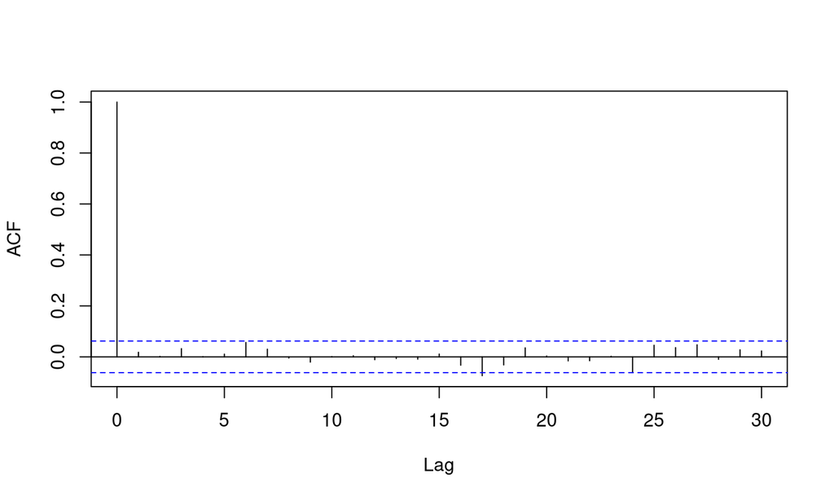

## Assumptions 4

- Non-independence

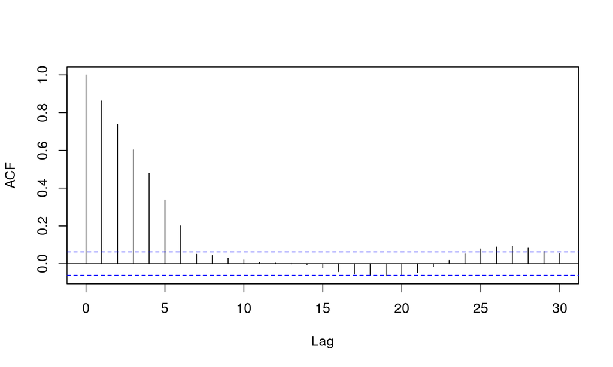